# U4L11 - Support Vector Machines

## Front Matter

```r
#Delete all objects from Environment - Use with caution
remove(list = ls())

#Load Libraries
library(tidyverse)
library(e1071)
#Read in Data
heart <- read.csv("../../sample_data/L11_heart.csv")
```

## Example - 2-dimensional Hyperplane

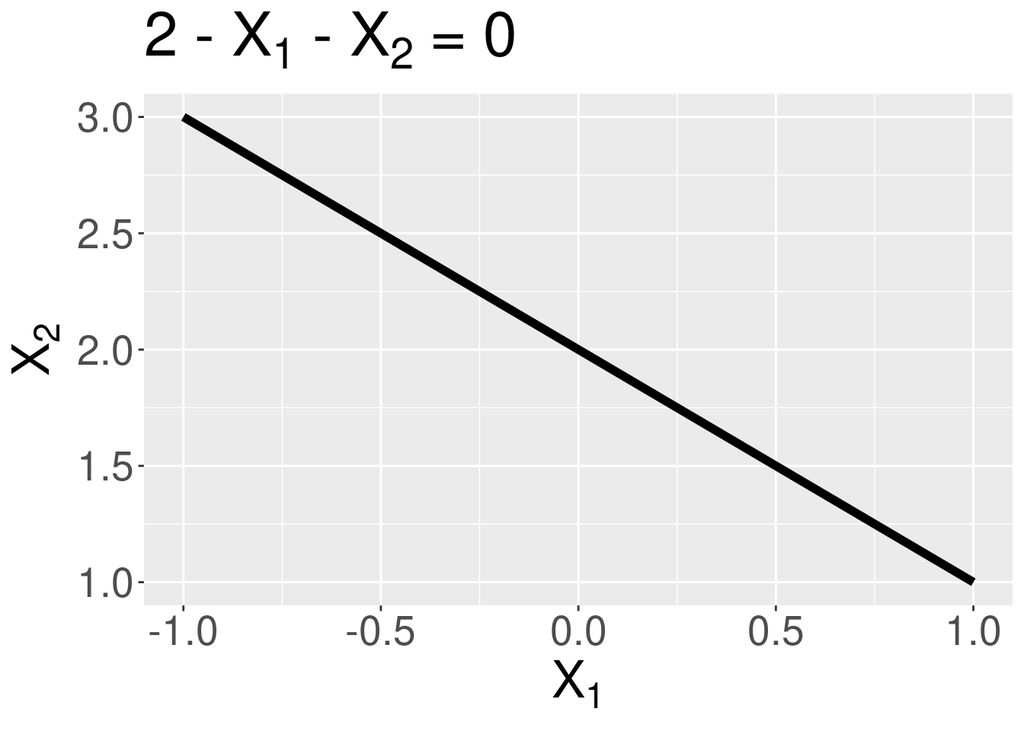

```r
#Create a data frame containing the information
x1 <- seq(-1, 1, length = 10) #Create a sequence of x1 values
f <- function(x1){ #Define a function for calculating x2
  x2 = 2 - x1
}

tempDF <- data.frame(x1 = x1, x2 = f(x1))

lineplot <-
  ggplot(data = tempDF, mapping = aes(x = x1, y = x2)) +
  geom_line(linewidth = 2)+
  labs(title = expression("2 - X"[1]*" - X"[2]*" = 0"),
       x = expression("X"[1]),
       y = expression("X"[2])) +
  theme(axis.title = element_text(size = 25),
        axis.text = element_text(size = 20),
        title = element_text(size = 25))
lineplot
```

## Example - 3-dimensional hyperplane

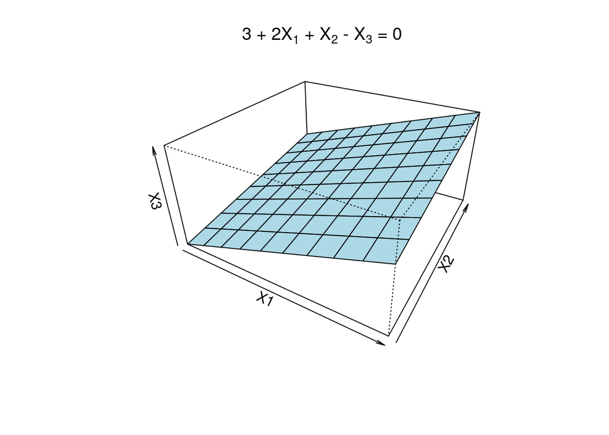

```r
x1 <- x2 <- seq(-1, 1, length= 10)
f <- function(x1,x2){
  z <- x1*2 + x2 + 3
}
x3 <- outer(x1,x2,f)
persp(x1, x2, x3, theta = 30, phi = 30, expand = 0.5, col = "lightblue",
      xlab = "X1", ylab = "X2", zlab = "X3")
title(main = expression("3 + 2X"[1]*" + X"[2]*" - X"[3]*" = 0"))
```

## Example - Motivating Example

#### Completely Separated

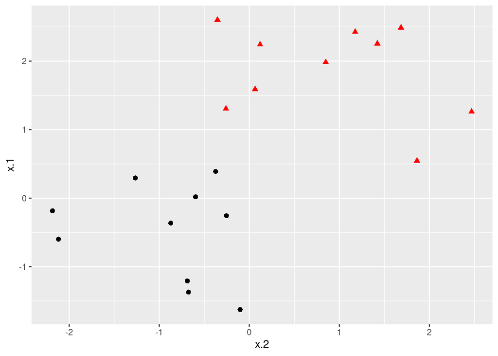

```r
# Set seed
set.seed(10)

# Construct sample data set - completely separated
x <- matrix(rnorm(20*2), ncol = 2)
y <- c(rep(-1,10), rep(1,10))
x[y==1,] <- x[y==1,] + 3/2
dat <- data.frame(x=x, y=as.factor(y))

# Plot data
wellsep <-
  ggplot(data = dat, aes(x = x.2, y = x.1, color = y, shape = y)) +
  geom_point(size = 2) +
  scale_color_manual(values=c("#000000", "#FF0000")) +
  theme(legend.position = "none")

wellsep
```

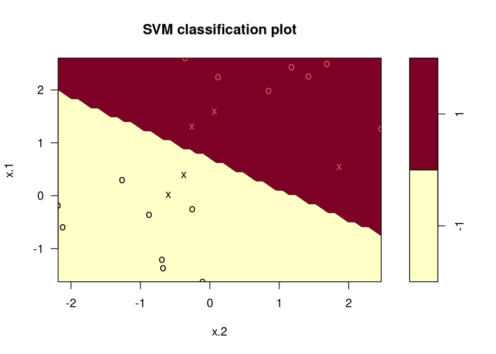

```r
#Built SVM
# Fit Support Vector Machine model to data set
svmfit <- svm(y~., data = dat, kernel = "linear", scale = FALSE)
#While y takes on values of 1 and 2, they are character "1" and "2". So, no need to convert to a factor. If they were numeric, convert y to a factor.

# Plot Results
plot(svmfit, dat)
```

#### Not Completely Separated (builds on seed from previous example)

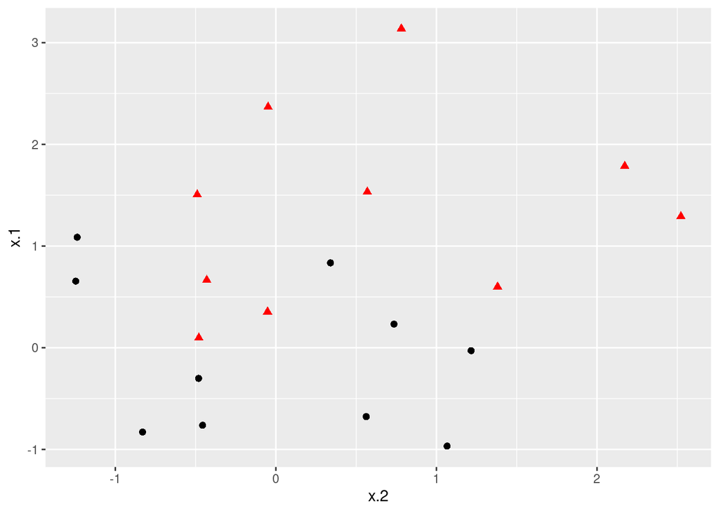

```r
# Construct sample data set - not completely separated
x <- matrix(rnorm(20*2), ncol = 2)
y <- c(rep(-1,10), rep(1,10))
x[y==1,] <- x[y==1,] + 1
dat <- data.frame(x=x, y=as.factor(y))

# Plot data set
nonsep <-
  ggplot(data = dat, aes(x = x.2, y = x.1, color = y, shape = y)) +
  geom_point(size = 2) +
  scale_color_manual(values=c("#000000", "#FF0000")) +
  theme(legend.position = "none")

nonsep
```

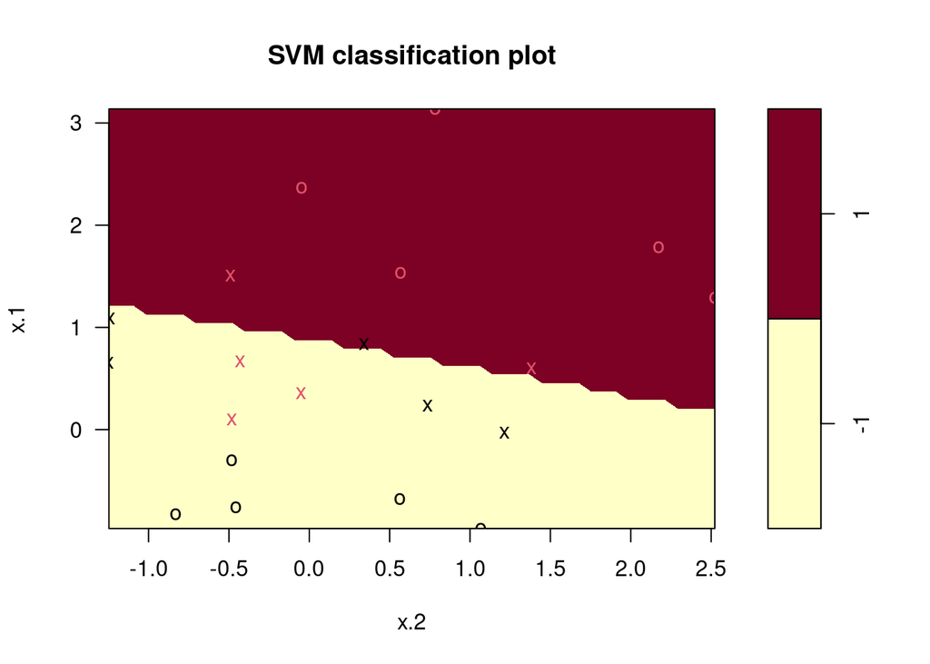

```r
# Fit Support Vector Machine model to data set
svmfit <- svm(y~., data = dat, kernel = "linear", scale = FALSE, cost = 10)
# Plot Results
plot(svmfit, dat)
```

#### Larger Dataset - Not Completely Separated (builds on seed from earlier)

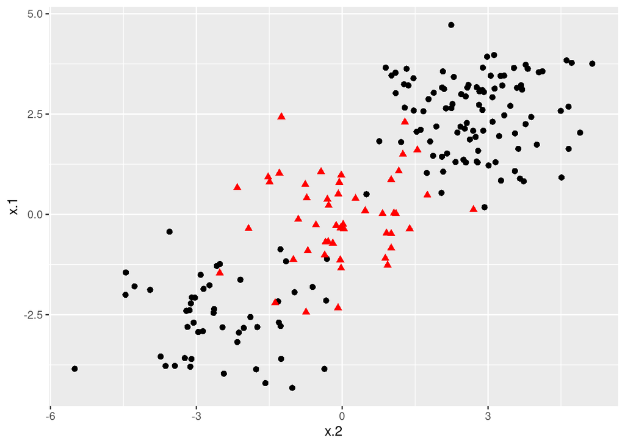

```r
# construct larger random data set
x <- matrix(rnorm(200*2), ncol = 2)
x[1:100,] <- x[1:100,] + 2.5
x[101:150,] <- x[101:150,] - 2.5
y <- c(rep(-1,150), rep(1,50))
dat <- data.frame(x=x,y=as.factor(y))

# Plot data
nonlinear <-
  ggplot(data = dat, aes(x = x.2, y = x.1, color = y, shape = y)) +
  geom_point(size = 2) +
  scale_color_manual(values=c("#000000", "#FF0000")) +
  theme(legend.position = "none")

nonlinear
```

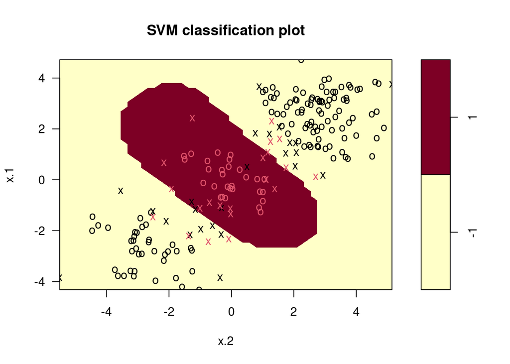

```r
# Build SVM
svmfit <- svm(y~., data = dat, kernel = "radial", gamma = 1, cost = 1)
# plot classifier
plot(svmfit, dat)
```

## Example - Motivating SVMs Part 1

#### Preliminaries - Generate the dataset

```r
#Generate Circle Data
set.seed(1432)
circle <- as.data.frame(mlbench::mlbench.circle(
  n = 200,
  d = 2
))
names(circle) <- c("x1", "x2", "y")  # rename columns
```

#### Preliminaries - Plot the datset

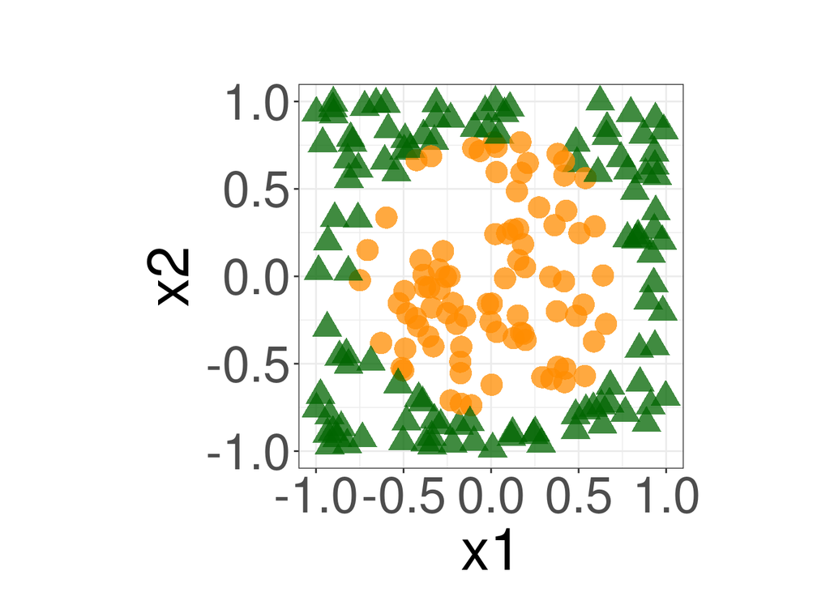

```r
baseCircle <-
  ggplot(data = circle, mapping = aes(x = x1, y = x2)) +
  geom_point(mapping = aes(color = y, shape = y), size = 6,
             alpha = 0.75, show.legend = FALSE) +
  labs(x = "x1",
       y = "x2",
       title = "") +
  xlim(-1, 1) +
  ylim(-1, 1) +
  coord_fixed() +
  theme_bw() +
  theme(axis.title = element_text(size = 35),
        axis.text = element_text(size = 30),
        title = element_text(size = 35),
        legend.title = element_text(size = 35),
        legend.text = element_text(size = 30)) +
  scale_color_manual(values=c("darkorange", "darkgreen"))

baseCircle
```

#### Part a - Explain why a linear decision boundary is inappropriate in this case.

No matter how you draw a linear through the points, the linear decision boundary will be a poor job of separating the classes.

#### Part b - Enlarge the feature space and plot

```r
#Create new feature (x3)
circle <-
  circle %>%
  mutate(x3 = x1^2 + x2^2)
```

```r
#Plot the data in 3d
rgl::plot3d(x = circle$x1, y = circle$x2, z = circle$x3,
            col = ifelse(circle$y == "1", "darkorange", "darkgreen"),
            xlab = "x1", ylab = "x2", zlab = "x3", size = 6,
            decorate = FALSE)
```

[output not shown]

```r
#Build Support Vector Classifier in 3D Space to find the separating hyperplane
svmModel <- svm(y ~ ., data = circle,
                kernel = "linear", cost = 10000, scale = FALSE)

#Display a summary of the model
summary(svmModel)
```

```
##
## Call:
## svm(formula = y ~ ., data = circle, kernel = "linear", cost = 10000,
##     scale = FALSE)
##
##
## Parameters:
##    SVM-Type:  C-classification
##  SVM-Kernel:  linear
##        cost:  10000
##
## Number of Support Vectors:  4
##
##  ( 2 2 )
##
##
## Number of Classes:  2
##
## Levels:
##  1 2
```

```r
coef(svmModel)
```

```
## (Intercept)          x1          x2          x3
##   55.009342    1.097191    1.723664  -87.590531
```

```r
#Plot the 3d data and decision boundary
rgl::plot3d(x = circle$x1, y = circle$x2, z = circle$x3,
            col = ifelse(circle$y == "1", "darkorange", "darkgreen"),
            xlab = "x1", ylab = "x2", zlab = "x3", size = 6,
            decorate = FALSE)
rgl::planes3d(a = coef(svmModel)[2],
              b = coef(svmModel)[3],
              c = coef(svmModel)[4],
              d = coef(svmModel)[1], alpha = 0.5)
```

[output not shown]

## Example - Motivating SVMs Part 2

#### Build a support vector machine for classifying y using x1 and x2. Use a polynomial kernel of degree 2 and a cost 10. Do not scale the data. Then plot, the result.

```r
#Build the model
svmModel <- svm(y~ x1 + x2, data = circle, kernel = "polynomial", degree = 2, cost = 10, scale = FALSE)
summary(svmModel)
```

```
##
## Call:
## svm(formula = y ~ x1 + x2, data = circle, kernel = "polynomial",
##     degree = 2, cost = 10, scale = FALSE)
##
##
## Parameters:
##    SVM-Type:  C-classification
##  SVM-Kernel:  polynomial
##        cost:  10
##      degree:  2
##      coef.0:  0
##
## Number of Support Vectors:  53
##
##  ( 26 27 )
##
##
## Number of Classes:  2
##
## Levels:
##  1 2
```

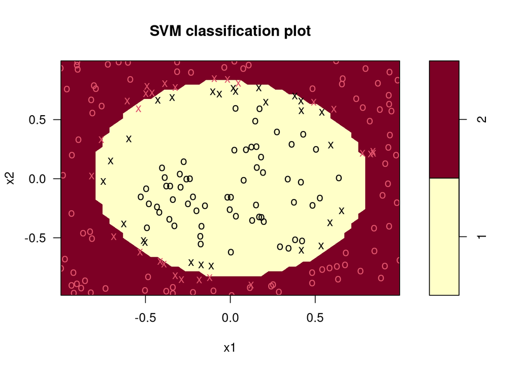

```r
#Plot the result
plot(svmModel, data = circle, formula = x2 ~ x1)
```

## Example - SVMs in R

#### Part a - Perform an 80/20 Training/Validation split using a seed of 123

```r
#Perform a Training/Validation Split
set.seed(123)
trainInd <- sample(1:nrow(heart), floor(0.8 * nrow(heart)))
set.seed(NULL)

Train <- heart[trainInd, ]
Validation <- heart[-trainInd, ]
```

#### Part b - Train a support vector machine classifier using a radial kernel based on γ=1. Use a cost of 10 and scale the dataset.

```r
#Build the Model
svmRadial <- svm(as.factor(HeartDisease) ~ ., data = Train, kernel = "radial", gamma = 1, cost = 10, scale = TRUE)

#Display a summary of the model
summary(svmRadial)
```

```
##
## Call:
## svm(formula = as.factor(HeartDisease) ~ ., data = Train, kernel = "radial",
##     gamma = 1, cost = 10, scale = TRUE)
##
##
## Parameters:
##    SVM-Type:  C-classification
##  SVM-Kernel:  radial
##        cost:  10
##
## Number of Support Vectors:  655
##
##  ( 379 276 )
##
##
## Number of Classes:  2
##
## Levels:
##  0 1
```

#### Part c - Calculate the accuracy on the validation set.

```r
#Predict the heart disease class
predHD <- predict(svmRadial, newdata = Validation)

#Produce the confusion matrix
table(predHD, Validation$HeartDisease)
```

```
##
## predHD  0  1
##      0 50  6
##      1 36 92
```

```r
#Calculate the accuracy and error
mean(predHD ==Validation$HeartDisease)
```

```
## [1] 0.7717391
```

```r
# Error rate is 1 - accuracy
1 - mean(predHD ==Validation$HeartDisease)
```

```
## [1] 0.2282609
```

```r
#Tune the model
tune.out <- tune(svm, as.factor(HeartDisease) ~.,
                 data = Train,
                 kernel = "radial",
                 ranges = list(cost = c(0.001, 0.01, 0.1, 1, 5, 10,100),
                               gamma = c(0.5, 1, 2, 3, 4)))

#Provide a summary
summary(tune.out)
```

```
##
## Parameter tuning of 'svm':
##
## - sampling method: 10-fold cross validation
##
## - best parameters:
##  cost gamma
##     1   0.5
##
## - best performance: 0.1538874
##
## - Detailed performance results:
##     cost gamma     error dispersion
## 1  1e-03   0.5 0.4413180 0.06882926
## 2  1e-02   0.5 0.4413180 0.06882926
```

[output cut: 33 more lines]

```r
#Find the optimal combination of cost and gamma
tune.out$best.parameters
```

```
##   cost gamma
## 4    1   0.5
```

#### Part e - Based on the optimal values of the tuning parameters, produce the confusion matrix and accuracy for the validation data.

```r
#Obtain predictions using the optimal combination of cost and gamma
predHD <- predict(tune.out$best.model, newdata = Validation)

#Create the confusion matrix
table(predHD, Validation$HeartDisease)
```

```
##
## predHD  0  1
##      0 59  9
##      1 27 89
```

```r
#Calculate the accuracy and error rate
mean(Validation$HeartDisease == predHD)
```

```
## [1] 0.8043478
```

```r
1 - mean(Validation$HeartDisease == predHD)
```

```
## [1] 0.1956522
```

#### Part f - How does the performance of the SVM classifier compare a logistic regression containing all of the features? (Use a threshold of 0.5.)

```r
#Build the logistic regression model
glmModel <- glm(as.factor(HeartDisease) ~.,
                data = Train,
                family = "binomial")

#Obtain the predicted probabilities and predicted classes
predProb <- predict(glmModel, newdata = Validation, type = "response")
threshold <- 0.5
predClass <- ifelse(predProb > threshold, 1, 0)

#Create the confusion matrix
table(predClass, Validation$HeartDisease)

#Calculate the accuracy and error rate
mean(predClass == Validation$HeartDisease)
1 - mean(predClass == Validation$HeartDisease)
```

[output not shown]